# R Notebook

```r
library(tidyverse)
library(modelr)
library(GGally)
library(ggfortify)
library(fastDummies)
```

```r
kc_house_data <- read_csv("data/kc_house_data.csv")
```

```r
glimpse(kc_house_data)
```

```
Rows: 21,613
Columns: 21
$ id            <chr> "7129300520", "6414100192", "5631500400", "2487200875", "1954400510", "7237550…
$ date          <dttm> 2014-10-13, 2014-12-09, 2015-02-25, 2014-12-09, 2015-02-18, 2014-05-12, 2014-…
$ price         <dbl> 221900, 538000, 180000, 604000, 510000, 1225000, 257500, 291850, 229500, 32300…
$ bedrooms      <dbl> 3, 3, 2, 4, 3, 4, 3, 3, 3, 3, 3, 2, 3, 3, 5, 4, 3, 4, 2, 3, 4, 3, 5, 2, 3, 3, …
$ bathrooms     <dbl> 1.00, 2.25, 1.00, 3.00, 2.00, 4.50, 2.25, 1.50, 1.00, 2.50, 2.50, 1.00, 1.00, …
$ sqft_living   <dbl> 1180, 2570, 770, 1960, 1680, 5420, 1715, 1060, 1780, 1890, 3560, 1160, 1430, 1…
$ sqft_lot      <dbl> 5650, 7242, 10000, 5000, 8080, 101930, 6819, 9711, 7470, 6560, 9796, 6000, 199…
$ floors        <dbl> 1.0, 2.0, 1.0, 1.0, 1.0, 1.0, 2.0, 1.0, 1.0, 2.0, 1.0, 1.0, 1.5, 1.0, 1.5, 2.0…
$ waterfront    <dbl> 0, 0, 0, 0, 0, 0, 0, 0, 0, 0, 0, 0, 0, 0, 0, 0, 0, 0, 0, 0, 0, 0, 0, 0, 0, 0, …
$ view          <dbl> 0, 0, 0, 0, 0, 0, 0, 0, 0, 0, 0, 0, 0, 0, 0, 3, 0, 0, 0, 0, 0, 4, 0, 0, 0, 0, …
$ condition     <dbl> 3, 3, 3, 5, 3, 3, 3, 3, 3, 3, 3, 4, 4, 4, 3, 3, 3, 4, 4, 4, 4, 3, 3, 3, 4, 5, …
$ grade         <dbl> 7, 7, 6, 7, 8, 11, 7, 7, 7, 7, 8, 7, 7, 7, 7, 9, 7, 7, 7, 7, 7, 9, 8, 7, 8, 6,…
$ sqft_above    <dbl> 1180, 2170, 770, 1050, 1680, 3890, 1715, 1060, 1050, 1890, 1860, 860, 1430, 13…
$ sqft_basement <dbl> 0, 400, 0, 910, 0, 1530, 0, 0, 730, 0, 1700, 300, 0, 0, 0, 970, 0, 0, 0, 0, 76…
$ yr_built      <dbl> 1955, 1951, 1933, 1965, 1987, 2001, 1995, 1963, 1960, 2003, 1965, 1942, 1927, …
$ yr_renovated  <dbl> 0, 1991, 0, 0, 0, 0, 0, 0, 0, 0, 0, 0, 0, 0, 0, 0, 0, 0, 0, 0, 0, 0, 0, 0, 0, …
$ zipcode       <dbl> 98178, 98125, 98028, 98136, 98074, 98053, 98003, 98198, 98146, 98038, 98007, 9…
$ lat           <dbl> 47.5112, 47.7210, 47.7379, 47.5208, 47.6168, 47.6561, 47.3097, 47.4095, 47.512…
$ long          <dbl> -122.257, -122.319, -122.233, -122.393, -122.045, -122.005, -122.327, -122.315…
$ sqft_living15 <dbl> 1340, 1690, 2720, 1360, 1800, 4760, 2238, 1650, 1780, 2390, 2210, 1330, 1780, …
$ sqft_lot15    <dbl> 5650, 7639, 8062, 5000, 7503, 101930, 6819, 9711, 8113, 7570, 8925, 6000, 1269…
```

Q1. Tidy up the data ready for regression:

1. You might like to think about removing some or all of date, id, sqft_living15, sqft_lot15 and zipcode (lat and long provide a better measure of location in any event).

```r
#I've left in the date in here. My logic is that even though the time range for sales is just over a year, seasonal fluctuations may influence the dependent variable of price (i.e. does the fact that less people selling/buying over the winter months impact the price of sales at this time). All others seem to be redundant or duplicates.

kc_house_trim <-
  kc_house_data %>%
  select(-c(id, sqft_living15, sqft_lot15, zipcode))

kc_house_trim
```

| date | price | bedrooms | bathrooms | sqft_living | sqft_lot | floors | waterfront | view | condition | grade | sqft_above | sqft_basement | yr_built | yr_renovated | lat | long |
| --- | --- | --- | --- | --- | --- | --- | --- | --- | --- | --- | --- | --- | --- | --- | --- | --- |
| 2014-10-13 | 221900 | 3 | 1.00 | 1180 | 5650 | 1.0 | 0 | 0 | 3 | 7 | 1180 | 0 | 1955 | 0 | 47.5112 | -122.257 |
| 2014-12-09 | 538000 | 3 | 2.25 | 2570 | 7242 | 2.0 | 0 | 0 | 3 | 7 | 2170 | 400 | 1951 | 1991 | 47.7210 | -122.319 |
| 2015-02-25 | 180000 | 2 | 1.00 | 770 | 10000 | 1.0 | 0 | 0 | 3 | 6 | 770 | 0 | 1933 | 0 | 47.7379 | -122.233 |
| 2014-12-09 | 604000 | 4 | 3.00 | 1960 | 5000 | 1.0 | 0 | 0 | 5 | 7 | 1050 | 910 | 1965 | 0 | 47.5208 | -122.393 |
| 2015-02-18 | 510000 | 3 | 2.00 | 1680 | 8080 | 1.0 | 0 | 0 | 3 | 8 | 1680 | 0 | 1987 | 0 | 47.6168 | -122.045 |
| 2014-05-12 | 1225000 | 4 | 4.50 | 5420 | 101930 | 1.0 | 0 | 0 | 3 | 11 | 3890 | 1530 | 2001 | 0 | 47.6561 | -122.005 |
| 2014-06-27 | 257500 | 3 | 2.25 | 1715 | 6819 | 2.0 | 0 | 0 | 3 | 7 | 1715 | 0 | 1995 | 0 | 47.3097 | -122.327 |
| 2015-01-15 | 291850 | 3 | 1.50 | 1060 | 9711 | 1.0 | 0 | 0 | 3 | 7 | 1060 | 0 | 1963 | 0 | 47.4095 | -122.315 |
| 2015-04-15 | 229500 | 3 | 1.00 | 1780 | 7470 | 1.0 | 0 | 0 | 3 | 7 | 1050 | 730 | 1960 | 0 | 47.5123 | -122.337 |
| 2015-03-12 | 323000 | 3 | 2.50 | 1890 | 6560 | 2.0 | 0 | 0 | 3 | 7 | 1890 | 0 | 2003 | 0 | 47.3684 | -122.031 |

[output cut: 990 more lines]

2. Have a think about how to treat waterfront. Should we convert its type?

```r
#Converted type to logical for waterfront variable
kc_house_trim <-
  kc_house_trim %>%
  mutate(waterfront = as.logical(waterfront))
```

3. We converted yr_renovated into a renovated logical variable, indicating whether the property had ever been renovated. You may wish to do the same.

```r
kc_house_trim <-
  kc_house_trim %>%
  mutate(renovated = as.logical(yr_renovated)) %>%
  select(-yr_renovated)
```

4. Have a think about how to treat condition and grade? Are they interval or categorical ordinal data types?

```r
kc_house_trim %>%
  distinct(condition)
```

| condition |
| --- |
| 3 |
| 5 |
| 4 |
| 1 |
| 2 |

```r
kc_house_trim %>%
  distinct(grade)
```

| grade |
| --- |
| 7 |
| 6 |
| 8 |
| 11 |
| 9 |
| 5 |
| 10 |
| 12 |
| 4 |
| 3 |

[output cut: 2 more lines]

**It looks like both of these variables are interval data types being that the order matters and the difference between the levels contained within the variable is meaningful. Grade is a bit of a strange one though. Although it is referred to as an index in the description, it does state that 1-3 falls short of building construction and design, 7 has an average level of construction and design, and 11-13 have a high quality level of construction and design. I’m assuming that we could name the intervening levels on the scale if we wanted to (i.e. 1 = falls woefully short, 2 = falls fairly short, etc.) That didn’t make much sense, but I’m keeping it in anyways!**

Q2. Check for aliased variables using the alias() function (this takes in a formula object and a data set). [Hint - formula price ~ . says ‘price varying with all predictors’, this is a suitable input to alias()]. Remove variables that lead to an alias. Check the ‘Elements of multiple regression’ lesson for a dropdown containing further information on finding aliased variables in a dataset.

```r
alias(lm(price ~., data = kc_house_trim))
```

```
Model :
price ~ date + bedrooms + bathrooms + sqft_living + sqft_lot +
    floors + waterfront + view + condition + grade + sqft_above +
    sqft_basement + yr_built + lat + long + renovated

Complete :
              (Intercept) date bedrooms bathrooms sqft_living sqft_lot floors waterfrontTRUE view
sqft_basement  0           0    0        0         1           0        0      0              0
              condition grade sqft_above yr_built lat long renovatedTRUE
sqft_basement  0         0    -1          0        0   0    0
```

**It looks like we can drop sqft_basement as we know that any remaining space that is not assigned to the sqft_above variable but is contained within the sqft_living variable must be the extra basement space. It might be different if the sqft_above was named something slightly different or there was an extra variable (i.e. sqft_attic). In this case, however, if the square feet is internal (sqft_living, not sqft_lot) and is above ground then by process of elimination it must be subteranean i.e. in the basement. That was a lot of waffle after the fact of the computer pointing it out with two numbers. Now that I think about it, could probably just have got rid of sqft_living I think?**

```r
kc_house_trim <-
kc_house_trim %>%
  select(-sqft_basement)
```

Q3. Systematically build a regression model containing up to four main effects (remember, a main effect is just a single predictor with coefficient), testing the regression diagnostics as you go

1. splitting datasets into numeric and non-numeric columns might help ggpairs() run in manageable time, although you will need to add either a price or resid column to the non-numeric dataframe in order to see its correlations with the non-numeric predictors.

```r
kc_house_trim_numeric <- kc_house_trim %>%
  select_if(is.numeric)

kc_house_trim_nonnumeric <- kc_house_trim %>%
  select_if(function(x) !is.numeric(x))

kc_house_trim_nonnumeric$price <- kc_house_trim$price

ggpairs(kc_house_trim_numeric)
ggpairs(kc_house_trim_nonnumeric)
```

[output not shown]

**That produced a few too many results so I’m just going to split the numeric values up again. Hopefully, this doesn’t affect the results in any way, although can’t think off the top of my head why it would, is it no just detailing correlations between two variables at a time. As long as price is still in there it should be fine.

```r
kc_numeric_1 <-
kc_house_trim_numeric %>%
  select(-c(view:grade, yr_built:long))

kc_numeric_2 <-
kc_house_trim_numeric %>%
  select(c(price, view:grade, yr_built:long))
```

```r
ggpairs(kc_numeric_1)
ggpairs(kc_numeric_2)
ggpairs(kc_house_trim_nonnumeric)
```

[output not shown]

**Looks like we’ve got a list of correlations to get us started. As follows:**

*1. sqft_living - 70.2* *2. grade - 66.7* *3. sqft_above - 60.6* *4. bathrooms - 52.5* *5. view - 39.7* *6. lat - 30.7* *7. There also may be a slight correlation between renovated houses and price according to the boxplot.*

**Thoughts at this stage**

*1. I find it really surprising that one of the largest correlation values isn’t for shared between price and number of bedrooms. Makes me think that maybe I’ve not attached the right significance to the bedroom levels.*

*2. Similarly, i wonder if the grade variable is working correctly here as it seems like a very high correlation for what it is. Then again, it should be a good numeric quality that captures a lot in terms of aesthetics and that “it’s right” feeling that attracts people to certain properties.*

```r
model_1a_pr_liv <-
  lm(price ~ sqft_living, data = kc_house_trim)

summary(model_1a_pr_liv)
```

```
Call:
lm(formula = price ~ sqft_living, data = kc_house_trim)

Residuals:
     Min       1Q   Median       3Q      Max
-1476062  -147486   -24043   106182  4362067

Coefficients:
              Estimate Std. Error t value Pr(>|t|)
(Intercept) -43580.743   4402.690  -9.899   <2e-16 ***
sqft_living    280.624      1.936 144.920   <2e-16 ***
---
Signif. codes:  0 ‘***’ 0.001 ‘**’ 0.01 ‘*’ 0.05 ‘.’ 0.1 ‘ ’ 1

Residual standard error: 261500 on 21611 degrees of freedom
Multiple R-squared:  0.4929,    Adjusted R-squared:  0.4928
F-statistic: 2.1e+04 on 1 and 21611 DF,  p-value: < 2.2e-16
```

**Looks pretty good for the first correlation. Relatively high R-squared value and small p-value. However, the standard error looks pretty massive!

```r
kc_house_trim %>%
  summarise(mean(price))
```

| mean(price) |
| --- |
| 540088.1 |

So that’s about half of the mean which isn’t great. I’ll go have a look at some of the other leading contenders.

```r
model_1b_pr_grade <-
  lm(price ~ grade, data = kc_house_trim)

summary(model_1b_pr_grade)
```

```
Call:
lm(formula = price ~ grade, data = kc_house_trim)

Residuals:
    Min      1Q  Median      3Q     Max
-816988 -151958  -36158   97842 6046097

Coefficients:
            Estimate Std. Error t value Pr(>|t|)
(Intercept) -1056045      12256  -86.17   <2e-16 ***
grade         208458       1582  131.76   <2e-16 ***
---
Signif. codes:  0 ‘***’ 0.001 ‘**’ 0.01 ‘*’ 0.05 ‘.’ 0.1 ‘ ’ 1

Residual standard error: 273400 on 21611 degrees of freedom
Multiple R-squared:  0.4455,    Adjusted R-squared:  0.4454
F-statistic: 1.736e+04 on 1 and 21611 DF,  p-value: < 2.2e-16
```

*Quite samey results, but a little worse.*

```r
model_1c_pr_bath <-
  lm(price ~ bathrooms, data = kc_house_trim)

summary(model_1c_pr_bath)
```

```
Call:
lm(formula = price ~ bathrooms, data = kc_house_trim)

Residuals:
     Min       1Q   Median       3Q      Max
-1438157  -184525   -41525   113220  5925322

Coefficients:
            Estimate Std. Error t value Pr(>|t|)
(Intercept)    10708       6211   1.724   0.0847 .
bathrooms     250326       2760  90.714   <2e-16 ***
---
Signif. codes:  0 ‘***’ 0.001 ‘**’ 0.01 ‘*’ 0.05 ‘.’ 0.1 ‘ ’ 1

Residual standard error: 312400 on 21611 degrees of freedom
Multiple R-squared:  0.2758,    Adjusted R-squared:  0.2757
F-statistic:  8229 on 1 and 21611 DF,  p-value: < 2.2e-16
```

**Right so I think we’re going for the sqft_living as the first main effect**

```r
kc_house_t2 <- kc_house_trim %>%
  add_residuals(model_1a_pr_liv) %>%
  select(-c("price", "sqft_living"))

kc_house_tnum2 <- kc_house_t2 %>%
  select_if(is.numeric)

kc_house_tnonn2 <- kc_house_t2 %>%
  select_if(function(x) !is.numeric(x))

kc_house_tnonn2$resid <- kc_house_t2$resid
```

```r
kc_num2_a <-
kc_house_tnum2%>%
  select(-c(view:grade, yr_built:long))

kc_num2_b <-
kc_house_tnum2 %>%
  select(c(view:grade, yr_built:long, resid))
```

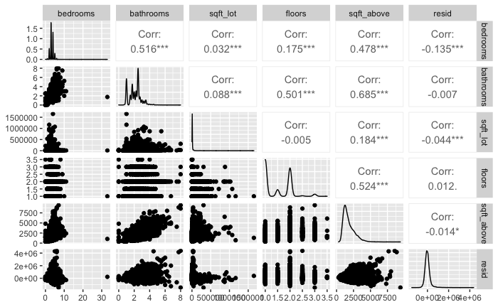

```r
#Second round of checks looking at the second main effect to use
ggpairs(kc_num2_a)
```

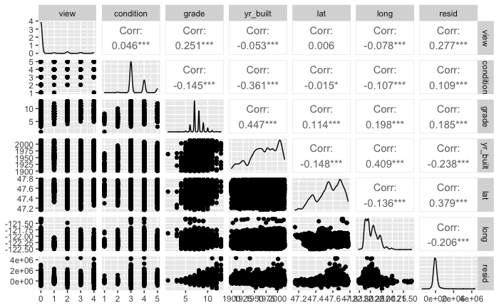

```r
ggpairs(kc_num2_b)
```

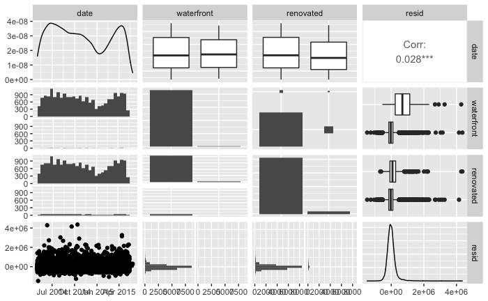

```r
ggpairs(kc_house_tnonn2)
```

**Wow, what a difference it makes when your just dealing with the residuals! Looks like our favourite “latitude” has just shot up the list (37.9). Definitely going to check this one out along with view (27.7) and yr_built (-23.8)**

```r
model_2a_pl_lat <-
  lm(price ~ sqft_living + lat, data = kc_house_trim)

summary(model_2a_pl_lat)
```

```
Call:
lm(formula = price ~ sqft_living + lat, data = kc_house_trim)

Residuals:
     Min       1Q   Median       3Q      Max
-1487994  -125643   -20309    84613  4368717

Coefficients:
              Estimate Std. Error t value Pr(>|t|)
(Intercept) -3.416e+07  5.653e+05  -60.44   <2e-16 ***
sqft_living  2.749e+02  1.794e+00  153.27   <2e-16 ***
lat          7.177e+05  1.189e+04   60.36   <2e-16 ***
---
Signif. codes:  0 ‘***’ 0.001 ‘**’ 0.01 ‘*’ 0.05 ‘.’ 0.1 ‘ ’ 1

Residual standard error: 241900 on 21610 degrees of freedom
Multiple R-squared:  0.566, Adjusted R-squared:  0.566
F-statistic: 1.409e+04 on 2 and 21610 DF,  p-value: < 2.2e-16
```

**R squared up to 56.6 and significance in the p-value. The standard error is also down.**

```r
model_2b_pl_view <-
  lm(price ~ sqft_living + view, data = kc_house_trim)

summary(model_2b_pl_view)
```

```
Call:
lm(formula = price ~ sqft_living + view, data = kc_house_trim)

Residuals:
     Min       1Q   Median       3Q      Max
-1583570  -139453   -19322   104245  4321083

Coefficients:
              Estimate Std. Error t value Pr(>|t|)
(Intercept) -16853.463   4257.279  -3.959 7.56e-05 ***
sqft_living    256.176      1.934 132.485  < 2e-16 ***
view        102951.162   2317.467  44.424  < 2e-16 ***
---
Signif. codes:  0 ‘***’ 0.001 ‘**’ 0.01 ‘*’ 0.05 ‘.’ 0.1 ‘ ’ 1

Residual standard error: 250300 on 21610 degrees of freedom
Multiple R-squared:  0.5353,    Adjusted R-squared:  0.5352
F-statistic: 1.245e+04 on 2 and 21610 DF,  p-value: < 2.2e-16
```

**Not quite as good, next yr-built**

```r
model_2c_pl_yr_blt <-
  lm(price ~ sqft_living + yr_built, data = kc_house_trim)

summary(model_2c_pl_yr_blt)
```

```
Call:
lm(formula = price ~ sqft_living + yr_built, data = kc_house_trim)

Residuals:
     Min       1Q   Median       3Q      Max
-1684544  -137797   -20753   105703  4036827

Coefficients:
              Estimate Std. Error t value Pr(>|t|)
(Intercept)  4.546e+06  1.206e+05   37.69   <2e-16 ***
sqft_living  3.046e+02  1.977e+00  154.03   <2e-16 ***
yr_built    -2.354e+03  6.183e+01  -38.07   <2e-16 ***
---
Signif. codes:  0 ‘***’ 0.001 ‘**’ 0.01 ‘*’ 0.05 ‘.’ 0.1 ‘ ’ 1

Residual standard error: 253100 on 21610 degrees of freedom
Multiple R-squared:  0.5247,    Adjusted R-squared:  0.5247
F-statistic: 1.193e+04 on 2 and 21610 DF,  p-value: < 2.2e-16
```

**So we’ll go with latitude for the second main effect**

```r
kc_house_t3 <- kc_house_trim %>%
  add_residuals(model_2a_pl_lat) %>%
  select(-c("price", "sqft_living", "lat"))

kc_house_tnum3 <- kc_house_t3 %>%
  select_if(is.numeric)

kc_house_tnonn3 <- kc_house_t3 %>%
  select_if(function(x) !is.numeric(x))

kc_house_tnonn3$resid <- kc_house_t3$resid
```

```r
kc_num3_a <-
kc_house_tnum3%>%
  select(-c(view:grade, yr_built:long))

kc_num3_b <-
kc_house_tnum3 %>%
  select(c(view:grade, yr_built:long, resid))
```

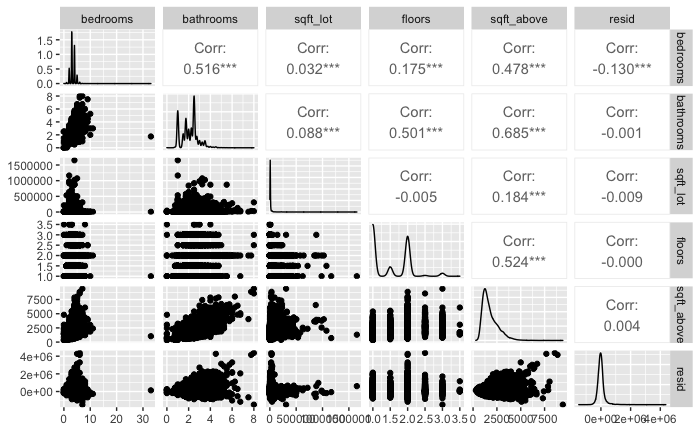

```r
#Third round of checks looking at the second main effect to use
ggpairs(kc_num3_a)
```

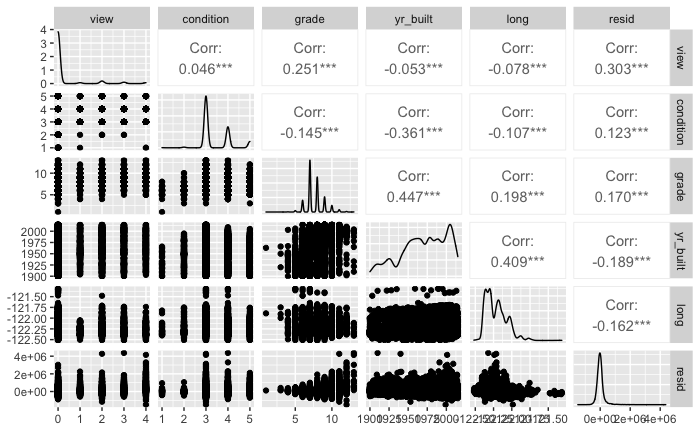

```r
ggpairs(kc_num3_b)
```

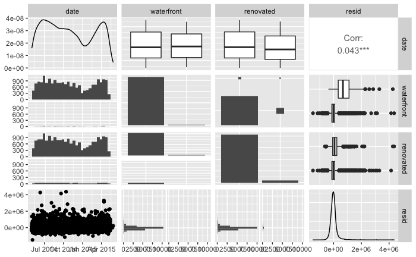

```r
ggpairs(kc_house_tnonn3)
```

**Looks like it’s view at 30.3, with yr built on -18.9 and we could even start to have a look at waterfront which seems to be showing a bit of difference**

```r
model_3a_pll_view <-
  lm(price ~ sqft_living + lat + view, data = kc_house_trim)

summary(model_3a_pll_view)
```

```
Call:
lm(formula = price ~ sqft_living + lat + view, data = kc_house_trim)

Residuals:
     Min       1Q   Median       3Q      Max
-1596893  -115223   -14728    82111  4327282

Coefficients:
              Estimate Std. Error t value Pr(>|t|)
(Intercept) -3.438e+07  5.363e+05  -64.11   <2e-16 ***
sqft_living  2.502e+02  1.775e+00  140.93   <2e-16 ***
lat          7.228e+05  1.128e+04   64.08   <2e-16 ***
view         1.042e+05  2.125e+03   49.05   <2e-16 ***
---
Signif. codes:  0 ‘***’ 0.001 ‘**’ 0.01 ‘*’ 0.05 ‘.’ 0.1 ‘ ’ 1

Residual standard error: 229400 on 21609 degrees of freedom
Multiple R-squared:  0.6095,    Adjusted R-squared:  0.6094
F-statistic: 1.124e+04 on 3 and 21609 DF,  p-value: < 2.2e-16
```

```r
model_3b_pll_yr_blt <-
  lm(price ~ sqft_living + lat + yr_built, data = kc_house_trim)

summary(model_3b_pll_yr_blt)
```

```
Call:
lm(formula = price ~ sqft_living + lat + yr_built, data = kc_house_trim)

Residuals:
     Min       1Q   Median       3Q      Max
-1645242  -120261   -14570    85543  4077885

Coefficients:
              Estimate Std. Error t value Pr(>|t|)
(Intercept) -2.770e+07  5.929e+05  -46.72   <2e-16 ***
sqft_living  2.936e+02  1.861e+00  157.79   <2e-16 ***
lat          6.551e+05  1.182e+04   55.40   <2e-16 ***
yr_built    -1.787e+03  5.875e+01  -30.42   <2e-16 ***
---
Signif. codes:  0 ‘***’ 0.001 ‘**’ 0.01 ‘*’ 0.05 ‘.’ 0.1 ‘ ’ 1

Residual standard error: 236900 on 21609 degrees of freedom
Multiple R-squared:  0.5838,    Adjusted R-squared:  0.5838
F-statistic: 1.011e+04 on 3 and 21609 DF,  p-value: < 2.2e-16
```

```r
model_3c_pll_waterfront <-
  lm(price ~ sqft_living + lat + waterfront, data = kc_house_trim)

summary(model_3c_pll_waterfront)
```

```
Call:
lm(formula = price ~ sqft_living + lat + waterfront, data = kc_house_trim)

Residuals:
     Min       1Q   Median       3Q      Max
-1386107  -119931   -17106    84803  4458444

Coefficients:
                 Estimate Std. Error t value Pr(>|t|)
(Intercept)    -3.465e+07  5.387e+05  -64.33   <2e-16 ***
sqft_living     2.665e+02  1.719e+00  155.07   <2e-16 ***
lat             7.282e+05  1.133e+04   64.27   <2e-16 ***
waterfrontTRUE  8.532e+05  1.822e+04   46.83   <2e-16 ***
---
Signif. codes:  0 ‘***’ 0.001 ‘**’ 0.01 ‘*’ 0.05 ‘.’ 0.1 ‘ ’ 1

Residual standard error: 230500 on 21609 degrees of freedom
Multiple R-squared:  0.606, Adjusted R-squared:  0.6059
F-statistic: 1.108e+04 on 3 and 21609 DF,  p-value: < 2.2e-16
```

**Oof, so it’s actually prettty close between view and waterfront. These two are probably closely related in terms of their effects. Let’s do a wee bit of comparison.

```r
anova(model_3a_pll_view, model_3c_pll_waterfront)
```

```
Analysis of Variance Table

Model 1: price ~ sqft_living + lat + view
Model 2: price ~ sqft_living + lat + waterfront
  Res.Df        RSS Df   Sum of Sq F Pr(>F)
1  21609 1.1375e+15
2  21609 1.1477e+15  0 -1.0174e+13
```

**So I’m taking a stab here and guessing that the negative value means that the second model (with waterfront) is slightly less significant. Really not sure though in terms of this, but will go with view for now as the third main effect.**

```r
kc_house_t4 <- kc_house_trim %>%
  add_residuals(model_3a_pll_view) %>%
  select(-c("price", "sqft_living", "lat", "view"))

kc_house_tnum4 <- kc_house_t4 %>%
  select_if(is.numeric)

kc_house_tnonn4 <- kc_house_t4 %>%
  select_if(function(x) !is.numeric(x))

kc_house_tnonn4$resid <- kc_house_t4$resid
```

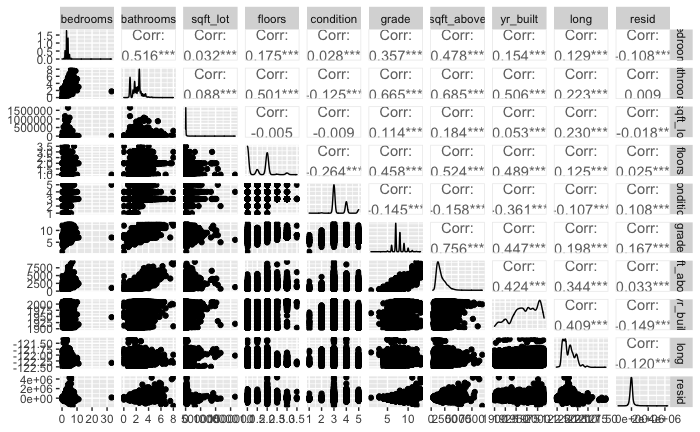

```r
#Fourth round of checks looking at the second main effect to use
ggpairs(kc_house_tnum4)
```

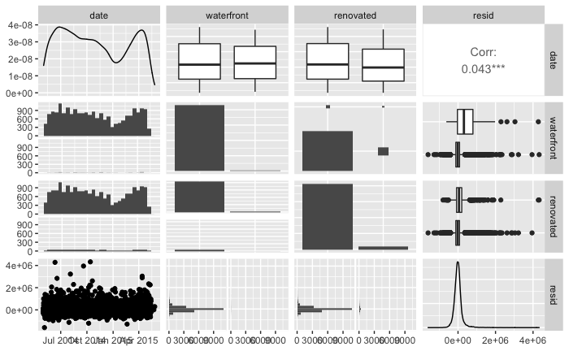

```r
ggpairs(kc_house_tnonn4)
```

**Looks like grade is making a late return. Will have a look at this (16.7), yr_built (-14.9) and longtitude (-12)**

```r
model_4a_pllv_grade <-
  lm(price ~ sqft_living + lat + view + grade, data = kc_house_trim)

summary(model_4a_pllv_grade)
```

```
Call:
lm(formula = price ~ sqft_living + lat + view + grade, data = kc_house_trim)

Residuals:
     Min       1Q   Median       3Q      Max
-1227675  -112956   -17345    77056  4676302

Coefficients:
              Estimate Std. Error t value Pr(>|t|)
(Intercept) -3.244e+07  5.201e+05  -62.38   <2e-16 ***
sqft_living  1.743e+02  2.569e+00   67.87   <2e-16 ***
lat          6.727e+05  1.096e+04   61.35   <2e-16 ***
view         9.959e+04  2.055e+03   48.47   <2e-16 ***
grade        7.921e+04  1.999e+03   39.63   <2e-16 ***
---
Signif. codes:  0 ‘***’ 0.001 ‘**’ 0.01 ‘*’ 0.05 ‘.’ 0.1 ‘ ’ 1

Residual standard error: 221500 on 21608 degrees of freedom
Multiple R-squared:  0.636, Adjusted R-squared:  0.6359
F-statistic:  9437 on 4 and 21608 DF,  p-value: < 2.2e-16
```

```r
model_4b_pllv_yr_built <-
  lm(price ~ sqft_living + lat + view + yr_built, data = kc_house_trim)

summary(model_4b_pllv_yr_built)
```

```
Call:
lm(formula = price ~ sqft_living + lat + view + yr_built, data = kc_house_trim)

Residuals:
     Min       1Q   Median       3Q      Max
-1708731  -111155   -10443    84211  4129084

Coefficients:
              Estimate Std. Error t value Pr(>|t|)
(Intercept) -2.941e+07  5.681e+05  -51.77   <2e-16 ***
sqft_living  2.664e+02  1.878e+00  141.87   <2e-16 ***
lat          6.744e+05  1.131e+04   59.62   <2e-16 ***
view         9.589e+04  2.125e+03   45.13   <2e-16 ***
yr_built    -1.370e+03  5.692e+01  -24.06   <2e-16 ***
---
Signif. codes:  0 ‘***’ 0.001 ‘**’ 0.01 ‘*’ 0.05 ‘.’ 0.1 ‘ ’ 1

Residual standard error: 226400 on 21608 degrees of freedom
Multiple R-squared:  0.6197,    Adjusted R-squared:  0.6196
F-statistic:  8802 on 4 and 21608 DF,  p-value: < 2.2e-16
```

```r
model_4c_pllv_long <-
  lm(price ~ sqft_living + lat + view + long, data = kc_house_trim)

summary(model_4c_pllv_long)
```

```
Call:
lm(formula = price ~ sqft_living + lat + view + long, data = kc_house_trim)

Residuals:
     Min       1Q   Median       3Q      Max
-1631812  -113878   -11962    84874  4226074

Coefficients:
              Estimate Std. Error t value Pr(>|t|)
(Intercept) -5.937e+07  1.438e+06  -41.29   <2e-16 ***
sqft_living  2.599e+02  1.837e+00  141.50   <2e-16 ***
lat          6.897e+05  1.133e+04   60.88   <2e-16 ***
view         9.777e+04  2.135e+03   45.78   <2e-16 ***
long        -2.172e+05  1.161e+04  -18.71   <2e-16 ***
---
Signif. codes:  0 ‘***’ 0.001 ‘**’ 0.01 ‘*’ 0.05 ‘.’ 0.1 ‘ ’ 1

Residual standard error: 227600 on 21608 degrees of freedom
Multiple R-squared:  0.6157,    Adjusted R-squared:  0.6156
F-statistic:  8655 on 4 and 21608 DF,  p-value: < 2.2e-16
```

**Ok think we’re going to go with this as the final model. Wish I had a bit more time to do a bit more refining and to check that I’m not doing anything daft, but that was quite good fun!

```r
final_model <- model_4a_pllv_grade
```